# Results Notebook (no outliers)

# 1 Overview

## 1.1 Data inspection

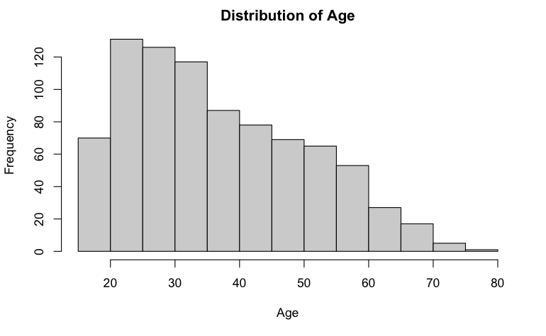

```r
hist(clean$AGE, main="Distribution of Age", xlab ="Age")
```

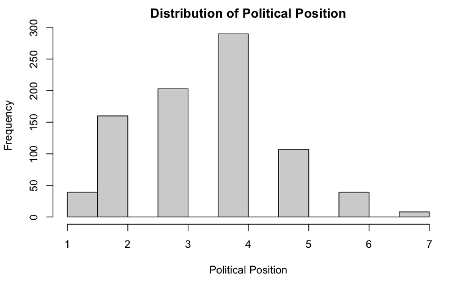

```r
hist(clean$POLITICS, main="Distribution of Political Position", xlab = "Political Position")
```

## 1.2 Participants

A total of 1146 participants were recruited through a survey posted on Prolific. 184 were excluded as they did not complete the survey, and 98 were excluded as they are vegan/vegetarian, and 5 were excluded for indicating that their results should not be included in the analysis. 13 were excluded for failing to select the correct response in an attention check. Using a robust Mahalanobis distance based on the Minimum Covariance Determinant, 56 multivariate outliers were detected and removed. The final sample (*N* = 790) ranged in age 18 to 79 (*Mdn<sub>age</sub>* = 35.00, *M<sub>age</sub>* = 37.35, *SD* = 13.54). The participants were predominantly female (56.84%). The participants received £0.35 ($0.45) for successfully completing the task.

## 1.3 Randomization check

A preliminary randomization check was conducted. The check revealed no systematic differences between the three conditions in gender, age, political position, and nationality (all *p*’s > .05).

```r
as_tibble(random_check, .name_repair = "unique") %>%
  kable(escape = F, col.names = c("Item", "Dynamic", "Static", "No norm", "Significance test"),
            caption="Randomisation check") %>%
  kable_styling()
```

[output not shown]

## 1.4 Correlations

```r
kable(measure.tib, caption = "Means, Standard Deviations, Reliabilities, and Inter-Correlations Among Study Measures") %>%
  kable_styling()
```

[output not shown]

# 2 Confirmatory analyses

## 2.1 Does making dynamic norms about reduced meat consumption in the UK salient lead to higher interest in reducing meat consumption (compared to static norm salience)?

### 2.1.1 Prior

Sparkman and Walton (2017) found effects of dynamic norms on interest in reducing meat consumption ranging from *M<sub>diff</sub>* = 0.60 – 0.78. Thus, the rough mean difference between dynamic and static norms expected in the sample is 0.69 on a 7 point Likert scale. Thus, I modeled H1 as a half-normal with an SD of 0.69. The plausible maximum effect was set at 1.38.

### 2.1.2 Results

The mean interest for participants in the dynamic norm condition was *M* = 3.60 (*SD* = 1.83), and the mean interest in the static norm condition was *M* = 3.63 (*SD* = 1.83). The mean interest in the no norm condition was *M* = 3.39 (*SD* = 1.73).

There was no difference in interest in reducing meat consumption between the dynamic norm (*M* = 3.60, *SD* = 1.83) and static norm (*M* = 3.63, *SD* = 1.83) conditions, $\Delta M = -0.03$, 95% CI $[-0.34$, $0.28]$, $t(787) = -0.18$, $p = .854$, *d* = -0.02, $B_{\text{HN}(0, 0.69)}$ = 0.19, RR[0.69, 2].

Participants in the no-norm control condition showed the least interest in reducing meat consumption (*M* = 3.39, *SD* = 1.73) and did not differ from those in the dynamic-norm condition $\Delta M = 0.21$, 95% CI $[-0.10$, $0.52]$, $t(787) = 1.31$, $p = .190$, *d* = 0.12, or the static-norm condition $\Delta M = 0.24$, 95% CI $[-0.07$, $0.54]$, $t(787) = 1.51$, $p = .130$, *d* = 0.13. There was also no difference between the dynamic-norm condition and a combination of the control and static-norm conditions $\Delta M = 0.09$, 95% CI $[-0.18$, $0.36]$, $t(787) = 0.65$, $p = .516$.

```r
apa_table(ls_interest$table, caption = "Meat consumption by condition contrasts", escape = F, row.names = F)
```

[output not shown]

### 2.1.3 Wordcloud

```r
comb_cloud <- rquery.wordcloud(comb_text, type ="text", lang = "english", min.freq = 5, excludeWords = c("reasons", "eating", "also", "meat", "people", "think", "much", "become", "due", "lot", "less", "eat", "consumption"))
```

[output not shown]

```r
cloud_freq <- head(comb_cloud$freqTable, 10)
apa_table(cloud_freq, caption = "Most frequent words in text", escape = F, row.names = F)
```

[output not shown]

## 2.2 Will participants in the dynamic norm condition be more likely (than those in the static norm control) to predict a future decrease in meat consumption in the UK?

I modeled H2 using a half-normal distribution with a mean of 0 and SD of *M<sub>diff</sub>* = 0.40. The plausible maximum effect was set at twice the predicted effect of *M<sub>diff</sub>* = 0.80. A Bayes factor was calculated for each test.

```r
kable(future, caption = "Expectations of future meat consumption", digits = 2, col.names = c("Condition", "$n$", rep(c("$M$", "$SD$"), 3))) %>%
  kable_styling() %>%
  add_header_above(c(" " = 2, "Future Norm" = 2, "Preconformity" = 2, "Combined" = 2))
```

[output not shown]

### 2.2.1 Measure of perception of change

> “In the next 5 years, I expect meat consumption in the UK to…”

There was no evidence one way or another for an effect of dynamic norm condition on expectations about future meat consumption, $\Delta M = 0.12$, 95% CI $[-0.01$, $0.25]$, $t(787) = 1.76$, $p = .079$, *d* = 0.15, $B_{\text{HN}(0, 0.40)}$ = 1.43, RR[0.05, 2]

```r
kable(ls_change$table, caption = "Contrasts between conditions in expectations about future meat consumption", escape = F, row.names = F) %>%
  kable_styling()
```

[output not shown]

### 2.2.2 Measure of preconformity

> “In the foreseeable future, to what extent do you think that many people will make an effort to eat less meat?”

There was no evidence one way or the other for there being a difference in anticipation that many people would make an effort to reduce their meat consumption in the future between the dynamic norm (*M* = 4.30, *SD* = 1.14) and static norm (*M* = 4.19, *SD* = 1.16) conditions, $\Delta M = 0.11$, 95% CI $[-0.09$, $0.31]$, $t(787) = 1.11$, $p = .269$, *d* = 0.10, $B_{\text{HN}(0, 0.40)}$ = 0.74, RR[0.05, 1.55].

```r
kable(ls_preconformity$table, caption = "Contrasts between conditions in preconformity", escape = F, row.names= F) %>%
  kable_styling()
```

[output not shown]

### 2.2.3 Combined

There was no evidence one way or the other for there being a difference in anticipation that many people would make an effort to reduce their meat consumption in the future between the dynamic norm (*M* = 4.81, *SD* = 0.85) and static norm (*M* = 4.70, *SD* = 0.83) conditions, $\Delta M = 0.11$, 95% CI $[-0.03$, $0.26]$, $t(787) = 1.59$, $p = .111$, *d* = 0.14, $B_{\text{HN}(0, 0.40)}$ = 1.14, RR[0.05, 2].

```r
kable(ls_comb_future$table, caption = "Combined contrasts", escape = F, row.names = F) %>%
  kable_styling()
```

[output not shown]

# 3 Secondary analyses

## 3.1 Will there be a difference in perceptions of current static norm across the dynamic and static norm conditions?

The SESOI for percentage difference is ± 5%. The SESOI for mean difference on the Likert scale is ± 0.5.

```r
TOSTtwo.sci(m1 = secondary[[1,4]], m2 = secondary[[2,4]], sd1 = secondary[[1,6]], sd2 = secondary[[2,6]], n1 = secondary[[1,2]], n2 = secondary[[2,2]], low_eqbound = -5, high_eqbound = 5, plot = F)
```

[output not shown]

## 3.2 Will there be a difference in how meat consumption is construed across the dynamic and static norm conditions?

```r
TOSTtwo.sci(m1 = secondary[[1,7]], m2 = secondary[[2,7]], sd1 = secondary[[1,8]], sd2 = secondary[[2,8]], n1 = secondary[[1,2]], n2 = secondary[[2,2]], low_eqbound = -5, high_eqbound = 5, plot = F)
```

[output not shown]

# 4 Exploratory analyses

## 4.1 Does dynamic norm (versus static norm) information lead to more positive attitudes, intentions, and expectations to reduce meat consumption?

### 4.1.1 Trace plots

```r
h3.traceplots[[1]] + ggtitle("Uninformative")
h3.traceplots[[2]] + ggtitle("Weak prior")
h3.traceplots[[1]] + ggtitle("Moderate prior")
```

[output not shown]

### 4.1.2 Posterior plots

```r
h3_intervals.plot
```

[output not shown]

```r
h3_density.grid
```

[output not shown]

### 4.1.3 Summary table

```r
h3.table %>%
  kable(format = "html", caption = "Posterior results for simple model (H3)", escape = F) %>%
  add_header_above(c(" " = 1, "Model 1: Uninformative priors$^a$" = 5, "Model 2: Weakly informative priors$^b$" = 6, "Model 3: Moderately informative priors$^c$" = 6)) %>%
  kable_styling() %>%
  footnote(general_title = "Note.",
           general = "PPI = posterior probability interval; PSRF = potential scale reduction factor; neff = effective sample size",
           alphabet = c(paste0("ppp = ", printp(h3.global[[1]][[3]])), paste0("ppp = ", printp(h3.global[[2]][[3]])), paste0("ppp = ", printp(h3.global[[3]][[3]]))),
           footnote_as_chunk = T) %>%
  landscape()
```

[output not shown]

## 4.2 Does age interact with norm condition to influence dependent variables?

### 4.2.1 Trace plots

```r
h4.traceplots[[1]] + ggtitle("Uninformative")
h4.traceplots[[2]] + ggtitle("Weak prior")
h4.traceplots[[1]] + ggtitle("Moderate prior")
```

[output not shown]

### 4.2.2 Posterior plots

```r
h4_intervals.plot
```

[output not shown]

### 4.2.3 Summary table (groups)

```r
interact.table %>%
  kable(format = "html", caption = "Posterior results for multi-sample analysis by age groups (H4)", row.names = F, escape = F) %>%
  add_header_above(c(" " = 1, "Model 1: Uninformative priors$^a$" = 5, "Model 2: Informative priors$^b$" = 6, "Model 3: Informative priors$^c$" = 6)) %>%
  kable_styling() %>%
  pack_rows("Young adults", 1, 3) %>%
  pack_rows("Middle-aged adults", 4, 6) %>%
  pack_rows("Old adults", 7, 9) %>%
  footnote(general_title = "Note.",
           general = "PPI = posterior probability interval; PSRF = potential scale reduction factor; neff = effective sample size",
           alphabet = c(paste0("ppp = ", printp(h4.global[[1]][["ppp"]])),
                        paste0("ppp = ", printp(h4.global[[2]][["ppp"]])),
                        paste0("ppp = ", printp(h4.global[[3]][["ppp"]]))),
           footnote_as_chunk = T) %>%
  landscape()
```

[output not shown]

### 4.2.4 Summary table (continuous)

```r
continuous_mod.out <- continuous_mod.out %>%
  mutate("        " = rep(c("Condition", "Age", "Condition $\\times$ Age"), 3))
```

[output not shown]

## 4.3 Do demographic factors such as age, gender, and political position predict the primary dependent variables?

### 4.3.1 Trace plots

```r
h5.traceplots[[1]] + ggtitle("Uninformative")
h5.traceplots[[2]] + ggtitle("Weak prior")
h5.traceplots[[1]] + ggtitle("Moderate prior")
```

[output not shown]

### 4.3.2 Posterior plots

```r
h5_intervals.plot
```

[output not shown]

```r
h5_density.plot
```

[output not shown]

### 4.3.3 Summary table

```r
h5.table %>%
  kable(format = "html", caption = "Posterior results for full model (H5)", row.names = F, escape = F) %>%
  kable_styling() %>%
  add_header_above(c(" " = 1, "Model 1: Uninformative priors$^a$" = 5, "Model 2: Informative priors$^b$" = 6, "Model 3: Informative priors$^c$" = 6)) %>%
  pack_rows("Interest", 1, 4) %>%
  pack_rows("Attitudes", 5, 8) %>%
  pack_rows("Intention/Expectations", 9, 12) %>%
  footnote(general_title = "Note.",
           general = "PPI = posterior probability interval; PSRF = potential scale reduction factor; neff = effective sample size",
           alphabet = c(paste0("ppp = ", printp(h5.global[[1]][["ppp"]])),
                        paste0("ppp = ", printp(h5.global[[2]][["ppp"]])),
                        paste0("ppp = ", printp(h5.global[[3]][["ppp"]]))), footnote_as_chunk = T) %>%
  landscape()
```

[output not shown]

# 5 Unregistered analyses

## 5.1 Power test

Sparkman and Walton (2017) found standardized effects of dynamic norms on interest in reducing meat consumption ranging from $d$ = 0.31 – 0.41. To detect the average effect of $d$ = 0.36, we would need 122 participants in each condition.

```r
h1.pwr
```

[output not shown]

## 5.2 Moderation of demographic variables

```r
attitude_mod.out$table <- attitude_mod.out$table %>%
  mutate(predictor = c("Intercept", "Condition", "Gender", "Political position", "Condition $\\times$ Gender", "Condition $\\times$ Political position"),
         rownames = NULL)
apa_table(attitude_mod.out$table, caption = "Exploring moderation of demographic variables on attitude", escape = F)
```

[output not shown]

```r
intent_mod.out$table <- intent_mod.out$table %>%
  mutate(predictor = c("Intercept", "Condition", "Gender", "Political position", "Condition $\\times$ Gender", "Condition $\\times$ Political position"),
         rownames = NULL)
apa_table(intent_mod.out$table, caption = "Exploring moderation of demographic variables on intentions/expectations", escape = F)
```

[output not shown]

```r
apa_table(demoreg.out$table, caption = "Exploring moderation of demographic variables on interest", escape = F)
```

[output not shown]

## 5.3 Mediation

```r
kable(med.table, escape = F, col.names = c("Parameter", "$M$", "$SD$", "Lower PPI", "Upper PPI", "PSRF", "Prior"), caption="Exploring mediating effect of attitude on intentions/expectations") %>%
  kable_styling()
```

[output not shown]

# 6 Environment and data

## 6.2 Codebook

```r
codebook::compact_codebook(no_out) %>%
  str()
```

[output not shown]